# XGBOOST Classification for Fantasy PL

Faiz MK

10 Oct 2018

This [R Markdown](http://rmarkdown.rstudio.com) Notebook is meant for our learning. Here, I try to use XGBOOST for classifying the top 1/3 player of the week. Each week you can choose from 500+ players to form your 15-player team (subject to many other conditions).

The idea is to shortlist and select among only the top 1/3 to form my team. This hypothetically can improve my odds to be above average. There will be further iteration in the future as I have more data and apply more advanced techniques in predicton.

## Data Aggregation & Setups

I pre-saved the data from FPL website into each week’s csv files, and use separate R script to combine all 7 weeks of data. This is to ensure code management is easier to understand.

```r
rm(list=ls())

library(utils, quietly=TRUE)   # for read.csv
library(dplyr, quietly=TRUE)   # for piping %>%
library(caret, quietly=TRUE)   # for training model
library(Matrix, quietly=TRUE)  # for sparse.model.matrix
library(xgboost, quietly=TRUE) # for xgboost model training
library(scales, quietly=TRUE)  # for rescale()
library(expss, quietly=TRUE)   # for tab_pivot()
source("./xgboost model common setup.R")
```

## Prepping Data for Train-Test

The data has to be prepped in the right format. XGBOOST model requires matrix data and the best is sparse matrix. Predictors (x’s) and target/label (y-hat) need to be defined separately.

```r
## Prep the train & test dataset, & subset to relevant variables. predictors from common setup
ixtrain = createDataPartition(df_merge88$tophalf, p=0.8, list=FALSE)
dftrain = df_merge88[ixtrain, c(predictors, targetclass)]
dftest  = df_merge88[-ixtrain, c(predictors, targetclass)]
## Convert predictors as sparse matrix. -1 to remove (Intercept) variable automatically created
sparse_data_train = sparse.model.matrix(object= (tophalf)~., data = dftrain)[,-1]
sparse_data_test = sparse.model.matrix(object= (tophalf)~., data = dftest)[,-1]
## Convert label as numeric. Target variable is also expected as a discrete numeric {0,1} and not factor.
labeltrn <- as.numeric(dftrain$tophalf)
labeltst = as.numeric(dftest$tophalf)
## Create a new xgb.DMatrix
dtrain = xgb.DMatrix(data=sparse_data_train, label=labeltrn)
dtest = xgb.DMatrix(data=sparse_data_test, label=labeltst)
```

## Training the XGBOOST Model

Training the model for classification. Key parameters set is eta=0.1 (lower learning rate than default for better accuracy, but longer run), subsample=0.3 & colsample_bytree=0.3 (allow the model to utilise min of 0.3 of samples/columns to form a tree), and gamma=5 (still don’t what it technically does, but higher number prevent the model from overfitting)

```r
## Train using XGBOOST classification model
## Cross Validation skip for now... maybe later.
## Advanced version using xgb.train. Simpler xgboost() avoided as it lack hyper parameters setting
## Use gamma=5 to regularize the model (before it tends to overfit)
xgbModel <- xgb.train(data = dtrain
                      , max_depth = 7
                      , min_child_weight = 1
                      , gamma = 5
                      , eta = 0.1
                      , nrounds = 700
                      , early_stopping_rounds = 50
                      , subsample = 0.3
                      , colsample_bytree = 0.3
                      , watchlist = list(train=dtrain, test=dtest)
                      , verbose = 1
                      , print_every_n = 10
                      , objective = "binary:logistic"
                      , eval_metric = "error"
                      )
```

[output not shown]

```r
## Predict on Test dataset & define the logistic probability cut off not by the probability itself,
## but rather based on probability quantile (of >0.66). This is to ensure that the model always pick
## the top 1/3 of the available players (normally 500+)
xgbpred <- predict(object=xgbModel, newdata=sparse_data_test)
xgbprediction = as.numeric(xgbpred>quantile(xgbpred, predprob_quant))
## Calculate the error rate (wrong prediction over total cases)
err = mean(xgbprediction!=labeltst)
paste0("Top 1/3 chosen, i.e. ", sum(xgbprediction), " out of ", length(xgbpred)) %>% print
```

```
## [1] "Top 1/3 chosen, i.e. 217 out of 638"
```

```r
paste0("The error rate is ", round(err,3)*100, "%") %>% print
```

```
## [1] "The error rate is 19.1%"
```

```r
data.frame(labeltst, prediction=xgbprediction) %>% table %>% print
```

```
##         prediction
## labeltst   0   1
##        0 367  68
##        1  54 149
```

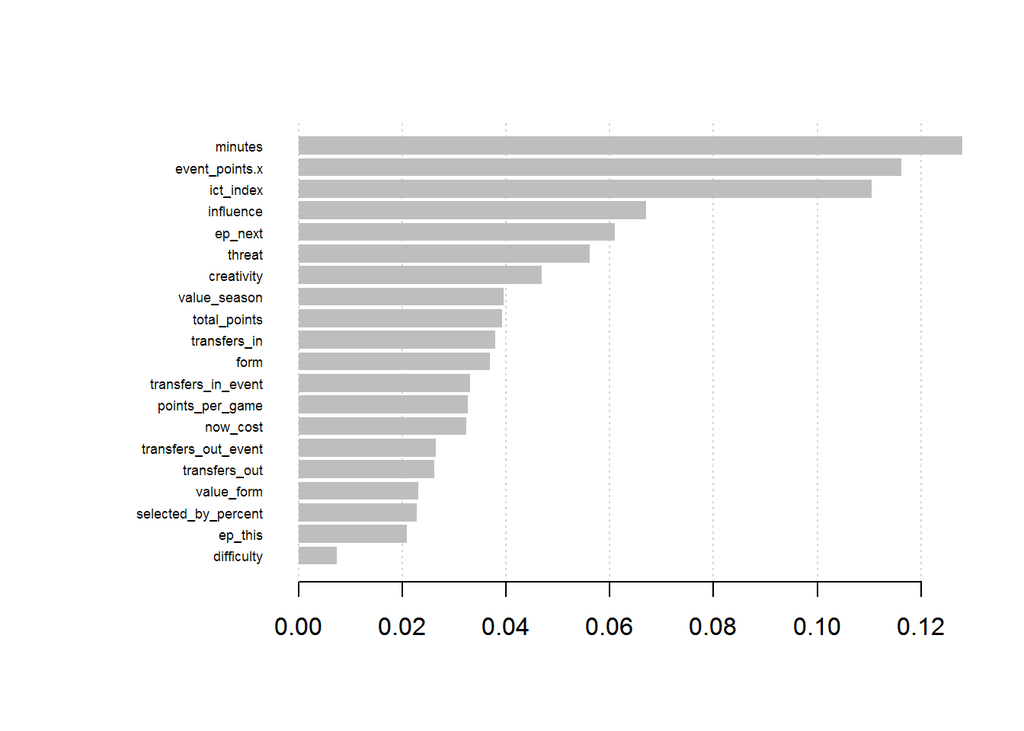

```r
## View feature importance/influence from the learnt model
## Feature importance is similar to R gbm package’s relative influence (rel.inf).
importance_matrix <- xgb.importance(colnames(sparse_data_train)
                                    , model = xgbModel
                                    )
xgb.plot.importance(importance_matrix = importance_matrix[1:20,])
```

## Testing on Actual Game Week

Now let’s test it on real data set i.e. predicting week 08 based on week 01-07 data. Would it fare well?

```r
## Define custom function to get prediction based on given XGBOOST model and transformed dataset
predict_tophalf = function(dfcurrweek, xgbModel){

  ## Supply data frame of the current week, mutate some of the variables and subset to
  ## relevant predictors only
  dfcurrweek = mutate(dfcurrweek
                      , special=as.factor(special)
                      , event_points.x=event_points
                      )
  dfcurrweek = dfcurrweek[,predictors]

  ## Convert predictors as sparse matrix. -1 to remove (Intercept) variable automatically created
  sparse_newdata = sparse.model.matrix(object= ~., data = dfcurrweek)[,-1]

  ## Prediction. Use median(currweekpred) to ensure I always get half of current week pop
  currweekpred = predict(object=xgbModel, newdata=sparse_newdata)
  currweekprediction = as.numeric(currweekpred>quantile(currweekpred, predprob_quant))

  ## cbind prediction outcome as dataframe
  dfcurrweekpred = cbind(tophalf_pred=currweekprediction, tophalf_conf=currweekpred) %>% as.data.frame
  return(dfcurrweekpred)
}

## Read & clean current and next Game Week data i.e. Summary & Fixtures dataset
df_currsumm = read.csv("./Data/week07_01summary.csv")  # current week
df_currfixt = read.csv("./Data/week07_04fixture.csv")  # current week next fixture
df_nextsumm = read.csv("./Data/week08_01summary.csv")  # next week
## Rescale them all. Do this for each week separately to ensure scale is not skewed by cumulative
## Then, feed transformed current week data into prediction
df_currweek = rescale_df(df_currsumm, df_currfixt)
df_nextweekpred = predict_tophalf(df_currweek, xgbModel)

## cbind current week with the prediction & merge with next week outcome
df_currweek = cbind(df_currweek, df_nextweekpred)
df_merge = merging_df(df_currweek,df_nextsumm)

## Print out cross-tab table of Game Week points, segregated by prediction (i.e. tophalf_pred ==0 / ==1)
df_merge %>%
  apply_labels(tophalf_pred="Prediction"
               , event_points.y="Next Week Actual Points") %>%
  tab_cells(event_points.y) %>%
  tab_cols(total() %nest% tophalf_pred, tophalf_pred %nest% element_type) %>%
  tab_stat_cases() %>%
  tab_pivot
```

|  | #Total Prediction 0 | #Total Prediction 1 |  | Prediction 0 DEF | Prediction 0 FWD | Prediction 0 GKP | Prediction 0 MID | Prediction | Prediction 1 DEF | Prediction 1 FWD | Prediction 1 GKP | Prediction 1 MID |
| --- | --- | --- | --- | --- | --- | --- | --- | --- | --- | --- | --- | --- |
| Next Week Actual Points |  |  |  |  |  |  |  |  |  |  |  |  |
| -4 | 1 |  |  | 1 |  |  |  |  |  |  |  |  |
| -2 | 1 | 1 |  | 1 |  |  |  |  |  |  |  | 1 |
| -1 |  | 2 |  |  |  |  |  |  | 2 |  |  |  |
| 0 | 259 | 20 |  | 105 | 29 | 37 | 88 |  | 8 | 1 | 2 | 9 |
| 1 | 45 | 35 |  | 12 | 10 |  | 23 |  | 5 | 11 | 1 | 18 |
| 2 | 18 | 54 |  | 5 | 1 | 1 | 11 |  | 15 | 9 | 4 | 26 |
| 3 | 8 | 20 |  |  |  | 3 | 5 |  |  |  | 3 | 17 |
| 4 | 1 | 2 |  | 1 |  |  |  |  |  | 1 |  | 1 |
| 5 | 4 | 11 |  | 2 | 1 |  | 1 |  | 5 | 5 |  | 1 |
| 6 | 6 | 17 |  | 4 | 1 | 1 |  |  | 14 |  | 1 | 2 |
| 7 | 4 | 6 |  | 2 |  |  | 2 |  | 3 |  | 1 | 2 |
| 8 | 3 | 1 |  | 1 |  |  | 2 |  | 1 |  |  |  |
| 9 | 3 | 5 |  | 1 |  | 2 |  |  |  | 2 | 2 | 1 |
| 10 | 1 | 2 |  |  |  |  | 1 |  |  |  |  | 2 |
| 11 | 1 |  |  | 1 |  |  |  |  |  |  |  |  |
| 12 |  | 1 |  |  |  |  |  |  |  | 1 |  |  |
| 13 | 1 | 2 |  |  |  |  | 1 |  |  | 1 |  | 1 |
| 14 |  | 2 |  |  |  |  |  |  |  | 1 |  | 1 |
| 15 |  | 2 |  |  |  |  |  |  | 1 | 1 |  |  |
| #Total cases | 356 | 183 |  | 136 | 42 | 44 | 134 |  | 54 | 33 | 14 | 82 |

```r
## Let's calculate actual Game Week prediction error rate
acttop = with(df_merge, (event_points.y>quantile(event_points.y,tophalf_quant)) %>% as.integer)
## Calculate the error rate (wrong prediction over total cases)
acterr = mean(df_merge$tophalf_pred!=acttop)
paste0("The actual GW error rate is ", round(acterr,3)*100, "%") %>% print
```

```
## [1] "The actual GW error rate is 20%"
```

```r
data.frame(actual=acttop, prediction=df_merge$tophalf_pred) %>% table %>% print
```

```
##       prediction
## actual   0   1
##      0 306  58
##      1  50 125
```

## Conclusion

We can see that the XGBOOST classification model quite successfully filter out players with Game Week points 1 and below.

The plan is to use this classification to filter out low-points players and then apply regression prediction as the objective to optimise (a proxy to next Game Week points prediction).

Currently, applying regression directly does not yield satisfactory results due to low accuracy (most likely due to lack of data)

*Thank you*